# Seminário Modelos Lineares

Giovanni Zini

2024-12-16

## Banco de dados

- Título: Sleep Health and Lifestyle Dataset
- Kaggle, por: Laksika Tharmalingam
- Dados Simulados
- $n = 374$

#### Variáveis Utilizadas

- `Blood Pressure` - Pressão Arterial (sistólica/diastólica)
- `Heart Rate` - Frêquencia Cardíaca em repouso
- `Daily Steps` - Número de Passos Diários
- `BMI Category` - Categoria do IMC

#### Variáveis Criadas

- `Mean Blood Pressure` - Pressão arterial média
  $$\large \frac{sistólica + 2(diastólica)}{3}$$
- `Daily Steps Thousand` = Número de Passos Diários (Mil)

## Objetivo

- Prever a pressão arterial média dos indivíduos com base no número de passos diários e na média de batimentos cardíacos em repouso.

$$\huge PressãoArterial = \beta_0 + \beta_1Frequência Cardíaca +
\beta_2Passos$$

## Estatística Descritiva

#### Densidade das variáveis explicativas e da variável resposta

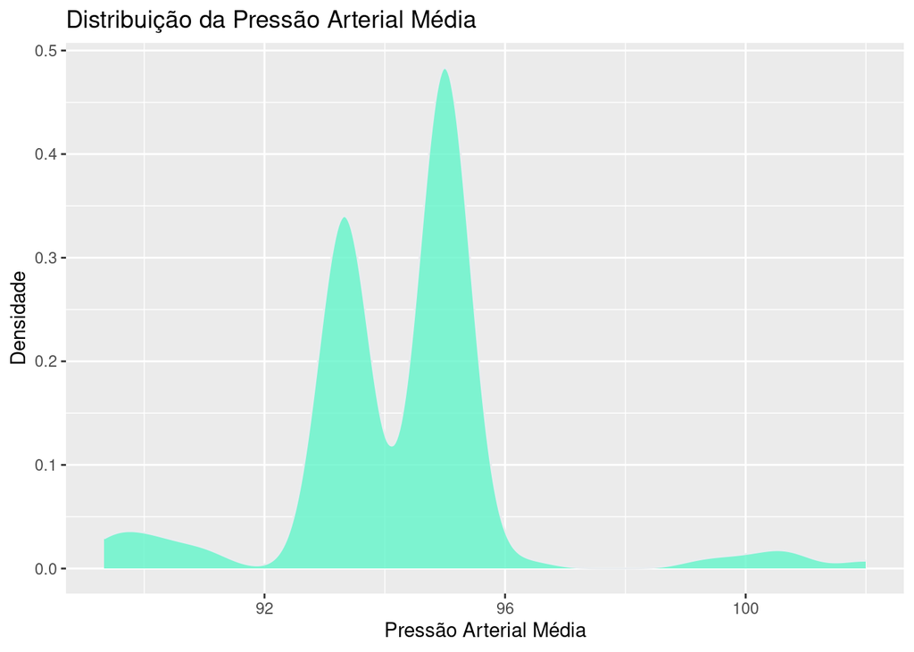

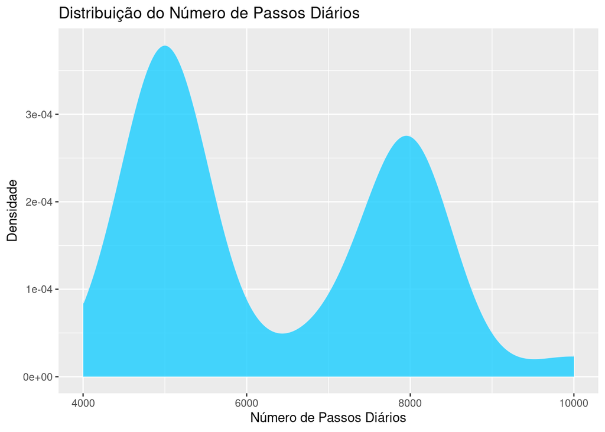

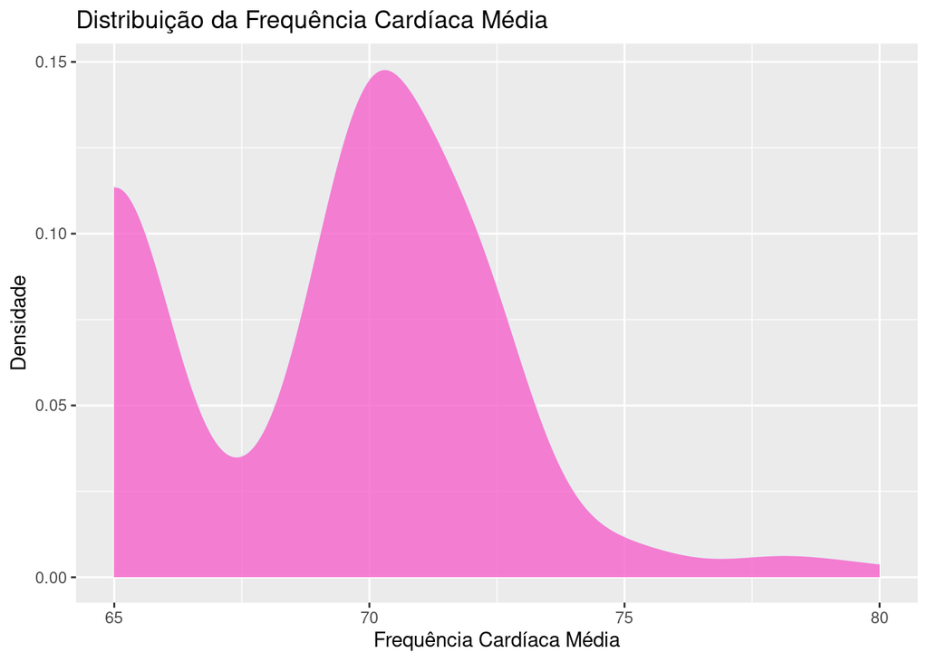

#### Dispersão Explicativa x Resposta:

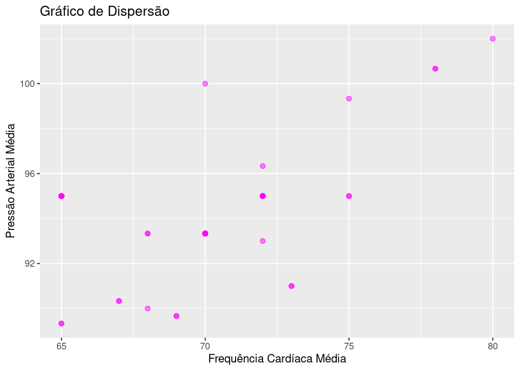

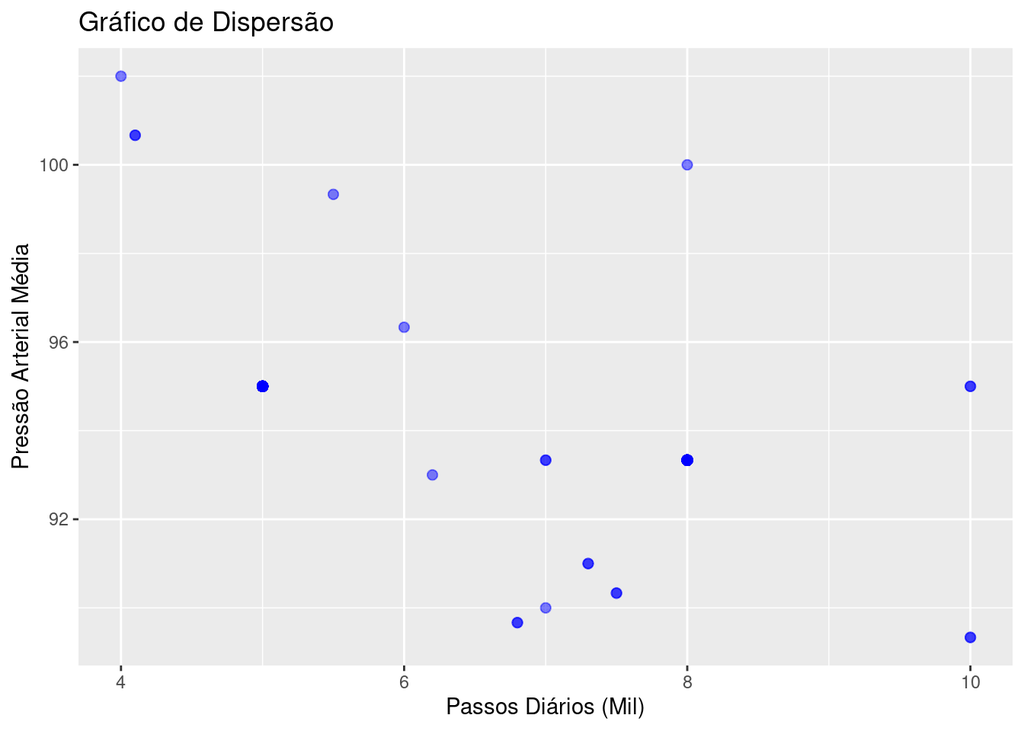

## Aplicação do Modelo Multivariado

#### Definições do modelo:

- Variáveis Explicativas: Número de passos diários (Mil) e Frequência Cardíaca Média (BPM)
- Variável Resposta: Pressão Arterial Média
- $n = 126$

#### Interpretação do fator de inflação de variância:

- $VIF = 1.035$, O que indica que o erro padrão para os coeficientes dessas variáveis preditoras é praticamente igual ao erro padrão teórico caso essas variáveis preditoras tivessem correlação igual a zero entre si.

#### Modelo ajustado:

$$\huge PressãoArterial = 85.04 + 0.207Frequência Cardíaca -0.804Passos$$

#### Interpretação dos coeficientes:

- $\beta_0 = 85.04$, Intercepto da reta de regressão, não há interpretação prática.
- $\beta_1 = 0.207$, O que indica que para um aumento de uma unidade da frequência cardíaca, dado que o número de passos diários seja fixo, há um aumento médio de 0,207 unidades na pressão arterial média.
- $\beta_2 = -0.804$, O que indica que para um aumento de mil passos diários, dado que a frequência cardíaca média seja fixa, há uma diminuição média de 0,804 unidades na pressão arterial média.

#### Interpretação do coeficiente de determinação:

- O valor de $R^2 = 0.497$, o que indica que 49,7% da variação da pressão arterial média está sendo explicada pelo número de passos diário e a frequência cardíaca média.

## Análise dos Resíduos

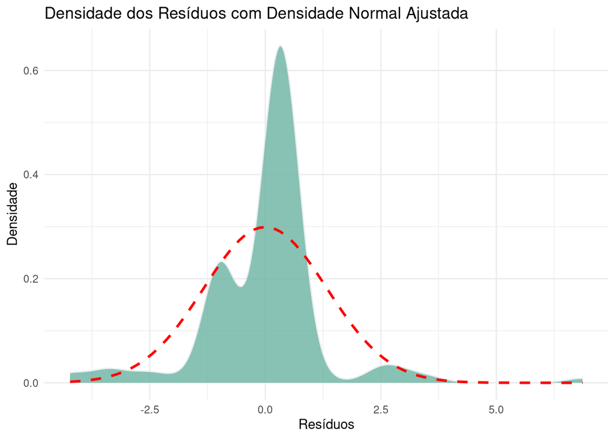

#### Interpretação do teste de normalidade Shapiro-Wilk:

- $H_0 =$ Normalidade dos Resíduos
- $H_1 =$ Não Normalidade dos Resíduos
- Estatística de Teste $W=0.777$
- P-valor $p = 1.488\times10^{-12}$
- Conclusão: Há evidências para rejeitarmos a hipótese nula de normalidade, portanto o modelo pode não estar bem ajustado.